# ACEt: An R package for estimating dynamic heritability and twin model comparison

Liang He

2023-05-23

# ACEt v1.9.0

## Installation

The R package can be installed from CRAN

```r
install.packages("ACEt")
```

The installation requires *Rcpp-0.11.1* and has been tested on *R-4.1.3*. The installation of the *ACEt* package also requires installing the *BH* and *RcppArmadillo* packages.

Please contact hyx520101@gmail.com for more information.

### Most recent version

To install the latest version from github:

```r
install.packages("devtools")
library(devtools)
install_github("lhe17/ACEt")
```

## Application to an example dataset

We illustrate how to utilize the *ACEt* R package with an example dataset that can be loaded with the following codes. More detail about the method is given in He et al. (2016) and He et al. (2017).

```r
library(ACEt)
data(data_ace)
```

The example dataset contains two matrices `mz` and `dz` for MZ and DZ twins, respectively. Each matrix includes 2500 twin pairs, of which the first two columns are the quantitative phenotype of the twin pair and the third column (`T_m` or `T_d`) is age.

```r
attributes(data_ace)
```

```
#> $names
#> [1] "mz" "dz"
```

```r
head(data_ace$mz)
```

```
#>                            T_m
#> [1,]  2.5638027  4.7355457   1
#> [2,] -3.1959902 -3.0133873   1
#> [3,]  1.3924694  2.8656795   1
#> [4,]  2.4519483  1.9145994   1
#> [5,] -0.4186678  1.3470608   1
#> [6,] -1.2805044 -0.5234272   1
```

```r
head(data_ace$dz)
```

```
#>                            T_d
#> [1,]  0.1402850 -0.3430456   1
#> [2,]  0.8588600 -0.7381698   1
#> [3,]  0.4025476  0.2794685   1
#> [4,] -0.4564107  0.2008932   1
#> [5,] -0.2458682 -3.0600677   1
#> [6,]  0.1459282  0.4588418   1
```

The age is distributed uniformly from 1 to 50 in both twin datasets and the phenotypes are normally distributed with a mean equal to zero. As discussed in He et al. (2017), before used as an input for this package, the phenotype should be centered, for example, by using residuals from a linear regression model `lm()` in which covariates for the mean function can be included. Fitting an ACE(t) model can be done by calling the `AtCtEt` function, in which users can specify a function (null, constant or splines) for each of the A, C, and E components independently through the `mod` argument.

```r
# fitting the ACE(t) model
re <- AtCtEt(data_ace$mz, data_ace$dz, mod = c('d','d','c'), knot_a = 6, knot_c = 4)
summary(re)
```

```
#>            Length Class  Mode
#> n_beta_a     1    -none- numeric
#> n_beta_c     1    -none- numeric
#> n_beta_e     1    -none- numeric
#> beta_a       7    -none- numeric
#> beta_c       5    -none- numeric
#> beta_e       1    -none- numeric
#> hessian_ap 169    -none- numeric
#> hessian    169    -none- numeric
#> con          1    -none- numeric
#> lik          1    -none- numeric
#> knots_a     10    -none- numeric
#> knots_c      8    -none- numeric
#> knots_e      2    -none- numeric
#> min_t        1    -none- numeric
#> max_t        1    -none- numeric
#> boot         0    -none- NULL
```

In the above script, an ACE(t) model is fitted for the example dataset. The first two arguments specify the matrices of the phenotypes for MZ and DZ twins, respectively. The argument `mod = c('d','d','c')` specifies that we allow the variances of the A and C components to change dynamically and assume the variance of the E component to be a constant over age. The `mod` argument is a vector of three elements corresponding to the A, C and E components that can be `'d', 'c' or 'n'`, in which `'n'` represents the exclusion of a component. For example, `mod = c('d','n','c')` indicates that we fit an AE model with a dynamic A component and a constant E component. It should be noted that the E component cannot be eliminated. We can also give the number of knots for each component, which is ignored if we choose `'c'` or `'n'` for that component. The number of randomly generated initial values for the estimation algorithm can be specified using the `robust` argument. Multiple initial values can be attempted to minimize the risk of missing the global maximum. The `AtCtEt` function returns both an expected and an approximate observed Fisher information matrices (shown below), which are close to each other in general and can be used to compute pointwise CIs. Note that the expected information matrix is always positive (semi)definite, but the approximated one is not necessarily positive definite. The returned value `lik` is the negative log-likelihood that can be used for LRT for the comparison of twin models.

```r
# part of the expected information matrix
re$hessian[1:8,1:8]
```

```
#>           [,1]      [,2]        [,3]         [,4]       [,5]       [,6]
#> [1,] 3.3122436  8.572181   0.9774334   0.00000000   0.000000   0.000000
#> [2,] 8.5721808 64.560338  43.2299744   2.22206265   0.000000   0.000000
#> [3,] 0.9774334 43.229974 145.2021892  67.94632724   2.836022   0.000000
#> [4,] 0.0000000  2.222063  67.9463272 182.31265682  68.569776   2.334633
#> [5,] 0.0000000  0.000000   2.8360218  68.56977584 155.634291  54.989838
#> [6,] 0.0000000  0.000000   0.0000000   2.33463321  54.989838 113.226897
#> [7,] 0.0000000  0.000000   0.0000000   0.00000000   1.840752  22.878770
#> [8,] 4.9109578 13.518421   2.7632296   0.02669836   0.000000   0.000000
#>           [,7]        [,8]
#> [1,]  0.000000  4.91095781
#> [2,]  0.000000 13.51842124
#> [3,]  0.000000  2.76322956
#> [4,]  0.000000  0.02669836
#> [5,]  1.840752  0.00000000
#> [6,] 22.878770  0.00000000
#> [7,] 11.077766  0.00000000
#> [8,]  0.000000 11.02095804
```

```r
# part the observed information matrix approximated by the L-BFGS algorithm
re$hessian_ap[1:8,1:8]
```

```
#>           [,1]      [,2]        [,3]         [,4]       [,5]       [,6]
#> [1,] 3.3066880  8.583804   0.9771341   0.00000000   0.000000   0.000000
#> [2,] 8.5838039 64.611733  43.1402778   2.22883073   0.000000   0.000000
#> [3,] 0.9771341 43.140278 144.8342062  67.91347006   2.836111   0.000000
#> [4,] 0.0000000  2.228831  67.9134701 181.14525247  67.405340   2.312405
#> [5,] 0.0000000  0.000000   2.8361108  67.40534018 155.154944  55.376537
#> [6,] 0.0000000  0.000000   0.0000000   2.31240520  55.376537 114.366468
#> [7,] 0.0000000  0.000000   0.0000000   0.00000000   1.856622  23.555961
#> [8,] 5.0462737 13.315584   2.7042919   0.02561431   0.000000   0.000000
#>           [,7]        [,8]
#> [1,]  0.000000  5.04627369
#> [2,]  0.000000 13.31558433
#> [3,]  0.000000  2.70429192
#> [4,]  0.000000  0.02561431
#> [5,]  1.856622  0.00000000
#> [6,] 23.555961  0.00000000
#> [7,] 11.486909  0.00000000
#> [8,]  0.000000 11.08078500
```

The `AtCtEt` function returns the minus log-likelihood evaluated at the estimates that is needed to make inference based on LRT. For example, the following program tests whether the A or C component has a constant variance with respect to age, we fit the null models and calculate the p-values based on $\chi^2$ distributions. It can be seen that the LRT has no sufficient statistical power to reject the constancy of the C component with this sample size (`p1>0.05`). In addition, we test whether the C component can be ignored by comparing `re_cc` and `re_cn` and compute the p-value (`p3`) based on a mixture of $\chi^2$ distributions.

```r
re_cc <- AtCtEt(data_ace$mz, data_ace$dz, mod = c('d','c','c'), knot_a = 6, knot_c = 4)
p1 <- pchisq(2*(re_cc$lik-re$lik), 4, lower.tail=FALSE)
p1
```

```
#> [1] 0.2079343
```

```r
re_ac <- AtCtEt(data_ace$mz, data_ace$dz, mod = c('c','d','c'), knot_a = 6, knot_c = 4)
p2 <- pchisq(2*(re_ac$lik-re$lik), 6, lower.tail=FALSE)
p2
```

```
#> [1] 8.937498e-12
```

```r
re_cn <- AtCtEt(data_ace$mz, data_ace$dz, mod = c('d','n','c'), knot_a = 6, knot_c = 4)
p3 <- 0.5*pchisq(2*(re_cn$lik-re_cc$lik), 1, lower.tail=FALSE)
p3
```

```
#> [1] 2.155026e-08
```

After fitting the ACE(t) model, we can plot the estimated variance curves by calling the `plot_acet` function.

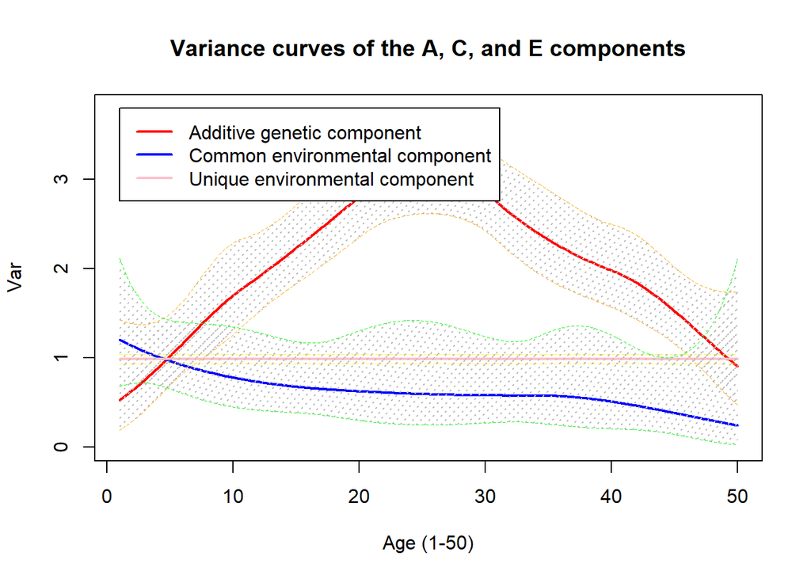

```r
plot_acet(re, ylab='Var', xlab='Age (1-50)')
```

By default, the 95% pointwise CIs are estimated using the delta method. Alternatively, we can choose the bootstrap method by setting `boot=TRUE` and giving the number of bootstrap resampling, the default value of which is 100.

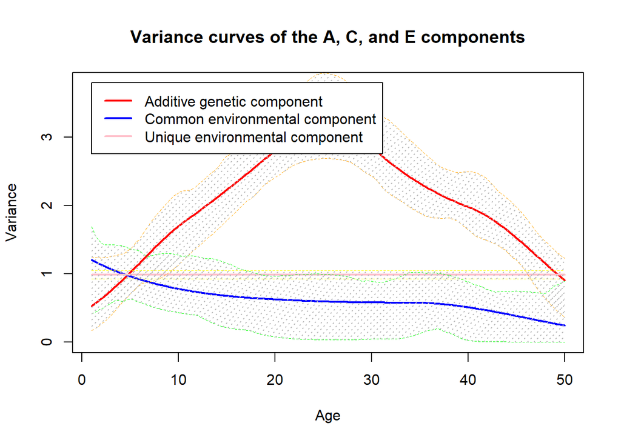

```r
## fitting an ACE(t) model with the CIs esitmated by the bootstrap method
re_b <- AtCtEt(data_ace$mz, data_ace$dz, mod = c('d','d','c'), knot_a = 6, knot_c = 4, boot = TRUE,
               num_b = 60)
plot_acet(re_b, boot = TRUE)
```

Next, we plot the age-specific heritability by setting the argument `heri=TRUE` in the `plot_acet` function. And similarly we can choose either the delta method or the bootstrap method to generate the CIs.

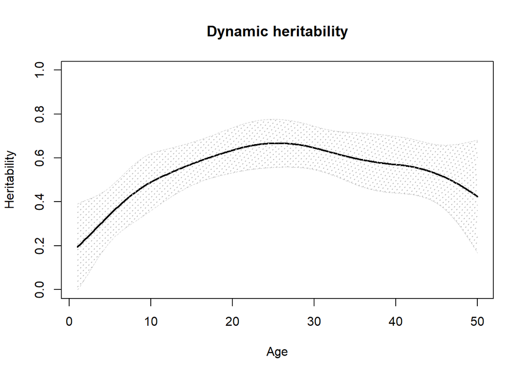

```r
## plot dynamic heritability with the CIs using the delta method
plot_acet(re_b, heri=TRUE, boot = FALSE)
```

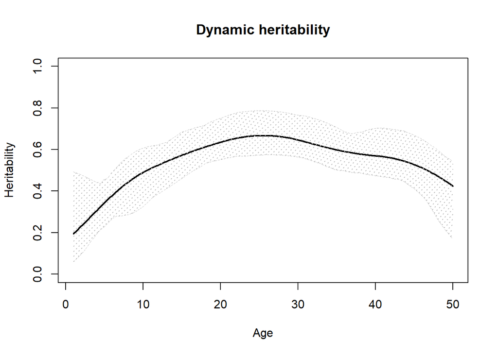

```r
## plot dynamic heritability with the CIs using the bootstrap method
plot_acet(re_b, heri=TRUE, boot = TRUE)
```

An ADE(t) model can be fitted and plotted similarly using the `AtDtEt` function as shown below.

```r
## fitting an ADE(t) model with the CIs esitmated by the bootstrap method
re_b <- AtDtEt(data_ace$mz, data_ace$dz, mod = c('d','d','c'), boot = TRUE, num_b = 60)
plot_acet(re_b, boot = TRUE)
```

[output not shown]

An ACE(t)-p model is a more stable model, which reduces the sensitivity to the number of knots by using P-splines. The ACE(t)-p model is implemented in the `AtCtEtp` function, in which users can choose exponential of penalized splines, a linear function or a constant to model a certain component by setting the `mod` argument. Compared to the ACE(t) model, it is not an essential problem to provide an excessive number of knots (the default value of interior knots is 8) when using the ACE(t)-p model as it is more important to ensure adequate knots for curves with more fluctuation than to avoid overfitting. Below, we fit the example dataset using the `AtCtEtp` function in which the A and C components are modelled by B-splines of 8 interior knots and the E component by a log-linear function. Similar to the `AtCtEt` function, we can use the `robust` argument to specify the number of randomly generated initial values, which can reduce the program’s possibility of being stuck on a local maximum in the EM algorithm.

```r
## fitting an ACE(t)-p model
re <- AtCtEtp(data_ace$mz, data_ace$dz, knot_a = 8, knot_c = 8, mod=c('d','d','l'))
summary(re)
```

```
#>         Length Class  Mode
#> D_a       81   -none- numeric
#> D_c       81   -none- numeric
#> D_e        4   -none- numeric
#> pheno_m 5000   -none- numeric
#> pheno_d 5000   -none- numeric
#> T_m     5000   -none- numeric
#> T_d     5000   -none- numeric
#> knot_a    12   -none- numeric
#> knot_c    12   -none- numeric
#> knot_e     2   -none- numeric
#> beta_a     9   -none- numeric
#> beta_c     9   -none- numeric
#> beta_e     2   -none- numeric
#> con        1   -none- numeric
#> lik        1   -none- numeric
#> iter       5   -none- numeric
#> var_b_a    1   -none- numeric
#> var_b_c    1   -none- numeric
#> var_b_e    1   -none- numeric
#> mod        3   -none- character
#> hessian    9   -none- numeric
```

The `AtCtEtp` function finds MLE of the variance $\sigma^{2}_{\beta^{A,C,E}}$ using the integrated likelihood and also provides estimates of the spline coefficients, i.e. $\beta^{A,C,E}$, which are based on maximum a posteriori (MAP) estimation. For a variance component of log-linearity (the E component in this example), $\beta$ is a vector of two elements that $exp(\beta)$ are the variances of this component at the minimum and maximum age in the dataset. To obtain the empirical Bayes estimates of $\beta^{A,C,E}$ and the covariance matrix using the MCMC method, we then call the `acetp_mcmc` function by plugging the result from the `AtCtEtp` function. We can also specify the numbers of the MCMC iterations and burn-in.

```r
re_mcmc <- acetp_mcmc(re, iter_num = 5000, burnin = 500)
summary(re_mcmc)
```

```
#>           Length Class  Mode
#> beta_a_mc   9    -none- numeric
#> beta_c_mc   9    -none- numeric
#> beta_e_mc   2    -none- numeric
#> cov_mc    400    -none- numeric
#> knots_a    12    -none- numeric
#> knots_c    12    -none- numeric
#> knots_e     2    -none- numeric
#> min_t       1    -none- numeric
#> max_t       1    -none- numeric
```

Given the esimates together with their covariance matrix, we can plot the variance curves or dynamic heritability by calling the `plot_acet` function. The `boot` option is ignored for the ACE(t)-p model.

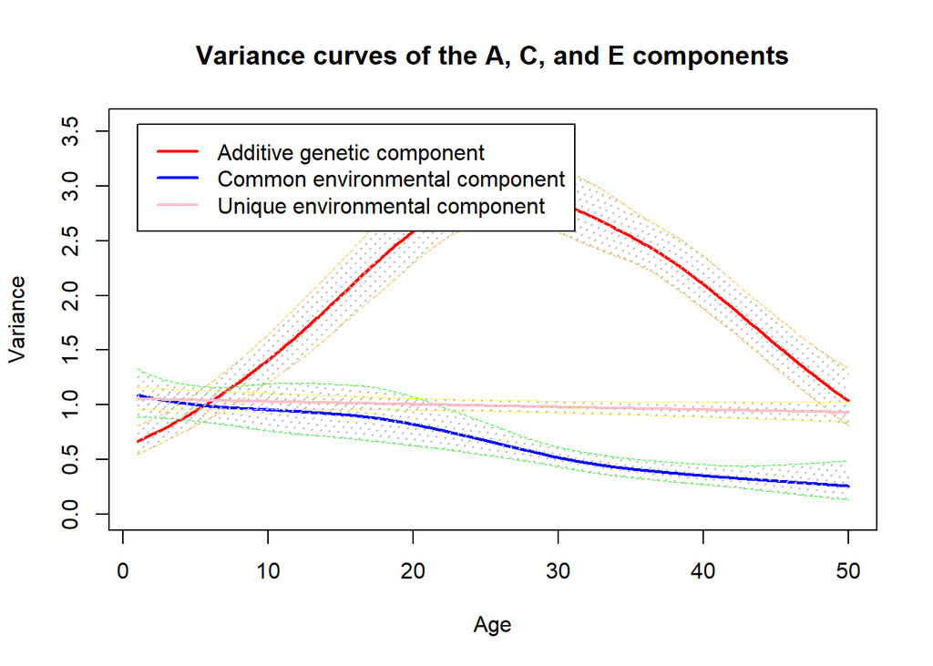

```r
plot_acet(re_mcmc)
```

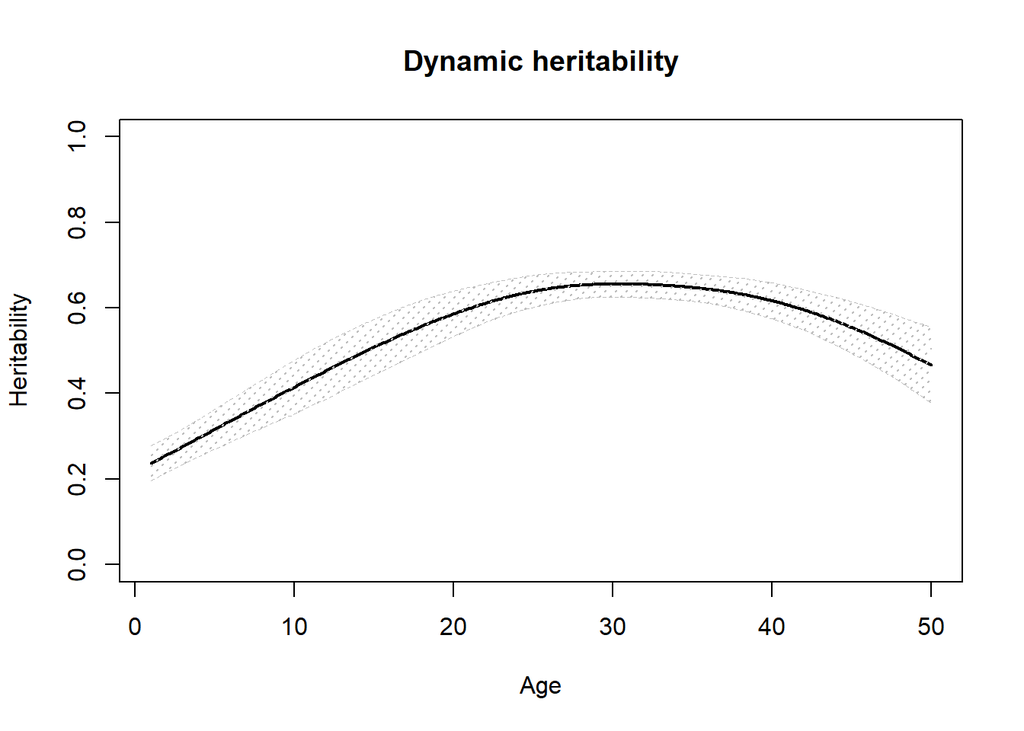

```r
plot_acet(re_mcmc, heri=TRUE)
```

Assigning too many knots in the ACE(t)-p model is much less harmful than that in the ACE(t) model. Comparing the following two plots from the application of the two models with 10 knots for each component to the example data set, it suggests that the ACE(t) model has an overfitting problem but the ACE(t)-p model works properly.

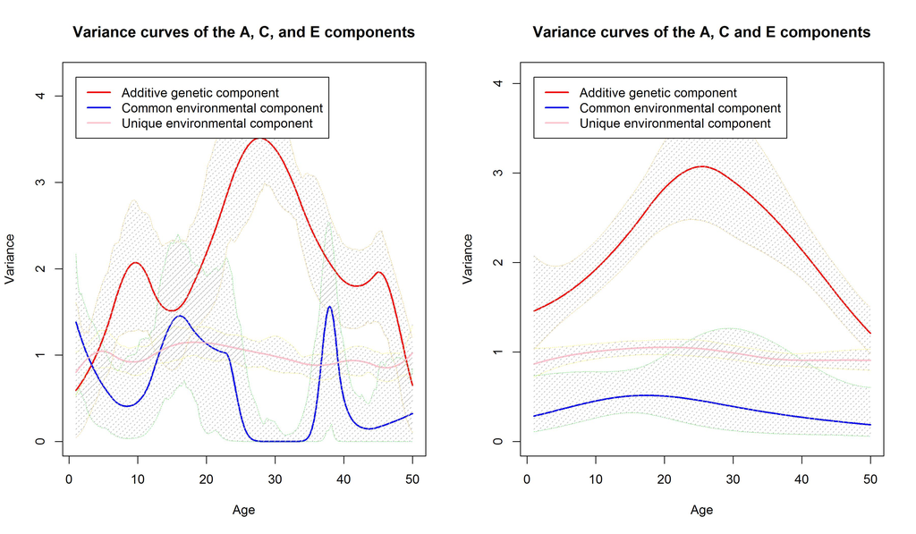

Plots of variance curves of the example data set fitted by the ACE(t) and ACE(t)-p model with 10 interior knots for each component. Left: the ACE(t) model. Right: the ACE(t)-p model.

Finally, we give an example to test a linear or constant variance curve. The `test_acetp` function is dedicated to the model comparison for the ACE(t)-p model and returns a p-value from LRT using a resampling method for testing log-linearity or from a $\chi^2$ distribution for testing constancy. First, the following code tests whether the E component is invariant with age. Before testing, we need to fit the data using the `AtCtEtp` function and obtain an `AtCtEtp_model` object `re`. Note that when testing a constant component, the component must be specified as log-linear when fitting the model (as shown above).

```r
test <- test_acetp(re, comp = 'e')
```

```
#> Model comparison:
#> [1] "Constancy (null) vs. Log-linear"
```

```r
test$p
```

```
#>           [,1]
#> [1,] 0.2648205
```

The result suggests that the E component is time-invariant as the p-value is larger than 0.05. Next, we test whether a log-linear model would be fitted better for the C component.

```r
test <- test_acetp(re, comp = 'c', sim = 100, robust = 0)
test$p
```

[output not shown]

## Reference

He, Liang, Janne Pitkäniemi, Karri Silventoinen, and Mikko J. Sillanpää. 2017. “ACEt : An r Package for Estimating 1 Dynamic Heritability and Comparing Twin Models.” *Behavior Genetics* 47 (6): 620–41.

He, Liang, Mikko J. Sillanpää, Karri Silventoinen, Jaakko Kaprio, and Janne Pitkäniemi. 2016. “Estimating Modifying Effect of Age on Genetic and Environmental Variance Components in Twin Models.” *Genetics* 202 (4): 1313–28.